[figure not shown]

**Machine Learning**  
MSE FTP MachLe  
Christoph Würsch

# Feature transformation

## (ii) Log, square, root transforms

A **monotonic transformation** is any function that **preserves the order of values**.

> If $x_1 > x_2$ then after transformation: $f(x_1) > f(x_2)$

| Transformation | Monotonic? | Comment | Image Feature Example |
| --- | --- | --- | --- |
| log(x) | ✔ | compresses large values | Spreads out dark pixels. Use case: Fourier spectrum, low-light enhancement. |
| sqrt(x) | ✔ | weaker compression | Dampens extreme lighting. Use case: HOG features, illumination normalization |
| x² (for x ≥ 0) | ✔ | amplifies differences | Spreads out bright pixels. Use case: Enhancing contrast in overexposed highlights. |

## (iii) Categorical features

**Nominal → one-hot encoding**

The data has no intrinsic order, for example colors.

[figure not shown]

One-hot encoding: for each category, create a new binary column. In the example, the first column indicates the color yellow, the second green, and the third blue.

It is an ideal method for nominal data with low cardinality.

**Ordinal → label encoding**

The data can be sorted, for example rating or rank.

[figure not shown]

Label encoding: each category is assigned an internal number. In the example, small=1, medium=2, large=3.

It is ideal for ordinal data.

### (iv) Problems with one-hot encoding (sparsity, curse of dimensionality)

1. Sparsity

When a categorical feature has many unique values (high cardinality), one-hot encoding creates a large number of binary columns — most of which will be 0 for any given sample.

Example: a city feature with 10,000 unique values produces 10,000 columns, where each row has exactly one 1 and 9,999 zeros.

```
      Milan  Rome  Naples  Turin  ... (9,996 more columns)
```

Sample 1: 1 0 0 0 ... 0 0 0 0 Sample 2: 0 1 0 0 ... 0 0 0 0 Sample 3: 0 0 0 0 ... 0 0 1 0

This results in a sparse matrix, which:

```
Wastes memory
Slows down training
Makes it harder for the model to find meaningful patterns
```

2. Curse of Dimensionality

Adding many binary columns means adding many dimensions to the feature space. This causes two major issues: 2a. Distances lose meaning

In high-dimensional spaces, all points tend to become equidistant from each other. This breaks models that rely on distance metrics (KNN, clustering).

Low dimensions → distances are meaningful ✅ High dimensions → all distances ≈ equal ❌

2b. Data becomes insufficient

As dimensions grow, the amount of data needed to represent the space grows exponentially.

10 features → ~1,000 samples needed 20 features → ~1,000,000 samples needed 30 features → ~1,000,000,000 samples needed

With too few samples relative to dimensions, models tend to overfit.

### (iv) Polynomial feature: The Land Price Analogy

In this notebook, we are going to predict the price of square plots of land.

- Our dataset only gives us one feature: the Side Length of the land in meters.
- We know that land is priced by Area, not by a straight line of length.  
  --> Let's see how a standard model struggles with this, and how feature transformation saves the day!

```python
import numpy as np
import matplotlib.pyplot as plt
from sklearn.linear_model import LinearRegression

# Set a random seed so our data is the same every time
np.random.seed(42)
```

### Step 1: The Raw Data

Let's generate 50 plots of land. The side lengths will be between 10 and 50 meters. In reality, the price is $500 per square meter (Area), plus a little bit of random noise to represent real-world market fluctuations.

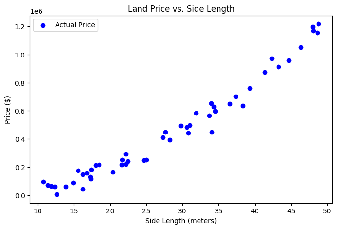

```python
# Generate 50 random side lengths between 10 and 50 meters
length = np.sort(np.random.uniform(10, 50, 50)).reshape(-1, 1)

# The true price is based on AREA (length squared) * $500, plus some noise
price = 500 * (length ** 2) + np.random.randn(50, 1) * 50000

# Let's plot our raw data!
plt.figure(figsize=(8, 5))
plt.scatter(length, price, color='blue', label='Actual Price')
plt.title("Land Price vs. Side Length")
plt.xlabel("Side Length (meters)")
plt.ylabel("Price ($)")
plt.legend()
plt.show()
```

### Step 2: The Stubborn Linear Model

Look at the graph above—it curves upwards! But our simple Linear Regression model only knows how to draw straight lines. It thinks: "Every extra meter of length adds a fixed amount of money." Let's see how badly it fails when we ask it to predict the prices based only on Length.

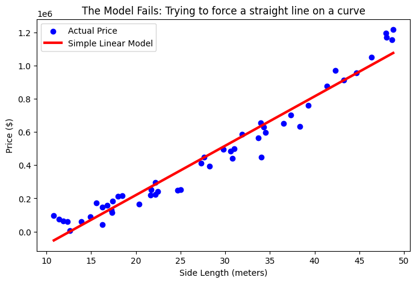

```python
# Train a standard linear model on the Length
stubborn_model = LinearRegression()
stubborn_model.fit(length, price)

# Predict the prices
predicted_price_bad = stubborn_model.predict(length)

# Plot the terrible fit
plt.figure(figsize=(8, 5))
plt.scatter(length, price, color='blue', label='Actual Price')
plt.plot(length, predicted_price_bad, color='red', linewidth=3, label='Simple Linear Model')
plt.title("The Model Fails: Trying to force a straight line on a curve")
plt.xlabel("Side Length (meters)")
plt.ylabel("Price ($)")
plt.legend()
plt.show()
```

### Step 3: Helping the Model Out (The Transformation)

The simple model is failing because it doesn't know how to calculate Area. So, we will do a Feature Transformation. We will take our Length feature, multiply it by itself, and create a brand-new feature called Area.

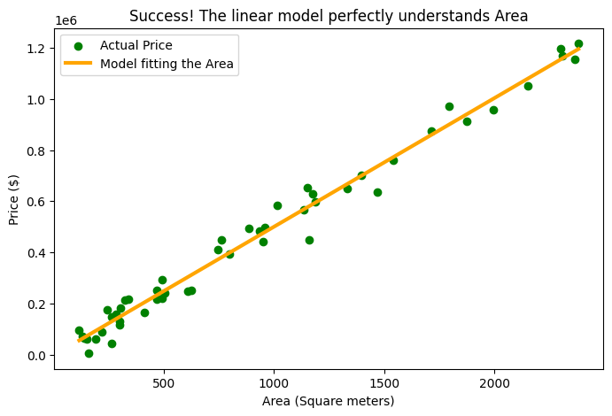

```python
# THE TRANSFORMATION: We create a new feature out of the old one
area = length ** 2

# Train a NEW linear model, but this time we feed it the 'Area' feature
smart_model = LinearRegression()
smart_model.fit(area, price)

# Predict the prices based on Area
predicted_price_good = smart_model.predict(area)

# Plot the amazing fit
plt.figure(figsize=(8, 5))
plt.scatter(area, price, color='green', label='Actual Price')
plt.plot(area, predicted_price_good, color='orange', linewidth=3, label='Model fitting the Area')
plt.title("Success! The linear model perfectly understands Area")
plt.xlabel("Area (Square meters)")
plt.ylabel("Price ($)")
plt.legend()
plt.show()
```

This notebook directly proves the point: you don't always need a complex, advanced AI to solve a curved problem. Sometimes, you just need to transform the data into a shape that a simple model can easily understand.

# (VI) Periodic Features in Machine Learning

In machine learning, **periodic features** are variables whose values repeat in a cycle. Common examples include:

- Hour of the day (0–23)
- Day of the week (Monday–Sunday)
- Month of the year (January–December)

These variables are **cyclical**, meaning that the end of the range is actually close to the beginning (e.g., 23:00 is close to 00:00). If encoded as normal integers, a model may incorrectly interpret these values as being far apart. To address this issue, special encoding techniques are used.

Two common approaches are:

- **Sine/Cosine Encoding**
- **Radial Basis Function (RBF) Encoding**

# 1. Sine / Cosine Encoding

Sine and cosine encoding maps a periodic variable onto a **unit circle**. This preserves the cyclical relationship between values.

[figure not shown]

# Key takeaways

- The Purpose: Models only understand specific types of math; transformations reshape raw data into a format the model can easily digest.
- Math Transforms (Log/Sqrt): Tame extreme outliers and fix heavily skewed data to make it look like a normal, predictable bell curve.
- Categorical Encoding: Use Label Encoding (1, 2, 3) for ordered data (Small/Medium/Large) and One-Hot Encoding (0 or 1 columns) for unordered data (Red/Green/Blue).
- One-Hot Pitfalls: High-cardinality data (like zip codes) creates massive, mostly empty datasets ("sparsity"), triggering the "curse of dimensionality" which slows down and confuses models.
- Polynomial Features: Multiply features by themselves or each other to help simple, straight-line models fit curved, non-linear relationships.
- Periodic Features: Use Sine/Cosine math or Radial Basis Functions to map cyclical data (like time or months) onto a circle, ensuring December logically connects back to January.